# Customer Churn Analytics

Guilherme Matheus

13/01/2020

Usaremos um dataset oferecido gratuitamente no portal IBM Sample Data Sets. Cada linha representa um cliente e cada coluna contém os atributos desse cliente.

Link: https://www.ibm.com/communities/analytics/watson-analytics-blog/guide-to-sample-datasets/

**Carregando os pacotes necessários:**

```r
library(plyr)
library(corrplot)
library(ggplot2)
library(gridExtra)
library(ggthemes)
library(caret)
library(MASS)
library(randomForest)
library(party)
```

### Carregando e Limpando os Dados

**Os dados brutos contém 7043 linhas (clientes) e 21 colunas (recursos) e a coluna “Churn” é o nosso alvo.**

```r
churn <- read.csv('Telco-Customer-Churn.csv')
View(churn)
str(churn)
```

```
## 'data.frame':    7043 obs. of  21 variables:
##  $ customerID      : Factor w/ 7043 levels "0002-ORFBO","0003-MKNFE",..: 5376 3963 2565 5536 6512 6552 1003 4771 5605 4535 ...
##  $ gender          : Factor w/ 2 levels "Female","Male": 1 2 2 2 1 1 2 1 1 2 ...
##  $ SeniorCitizen   : int  0 0 0 0 0 0 0 0 0 0 ...
##  $ Partner         : Factor w/ 2 levels "No","Yes": 2 1 1 1 1 1 1 1 2 1 ...
##  $ Dependents      : Factor w/ 2 levels "No","Yes": 1 1 1 1 1 1 2 1 1 2 ...
##  $ tenure          : int  1 34 2 45 2 8 22 10 28 62 ...
##  $ PhoneService    : Factor w/ 2 levels "No","Yes": 1 2 2 1 2 2 2 1 2 2 ...
##  $ MultipleLines   : Factor w/ 3 levels "No","No phone service",..: 2 1 1 2 1 3 3 2 3 1 ...
##  $ InternetService : Factor w/ 3 levels "DSL","Fiber optic",..: 1 1 1 1 2 2 2 1 2 1 ...
##  $ OnlineSecurity  : Factor w/ 3 levels "No","No internet service",..: 1 3 3 3 1 1 1 3 1 3 ...
##  $ OnlineBackup    : Factor w/ 3 levels "No","No internet service",..: 3 1 3 1 1 1 3 1 1 3 ...
##  $ DeviceProtection: Factor w/ 3 levels "No","No internet service",..: 1 3 1 3 1 3 1 1 3 1 ...
##  $ TechSupport     : Factor w/ 3 levels "No","No internet service",..: 1 1 1 3 1 1 1 1 3 1 ...
##  $ StreamingTV     : Factor w/ 3 levels "No","No internet service",..: 1 1 1 1 1 3 3 1 3 1 ...
##  $ StreamingMovies : Factor w/ 3 levels "No","No internet service",..: 1 1 1 1 1 3 1 1 3 1 ...
##  $ Contract        : Factor w/ 3 levels "Month-to-month",..: 1 2 1 2 1 1 1 1 1 2 ...
##  $ PaperlessBilling: Factor w/ 2 levels "No","Yes": 2 1 2 1 2 2 2 1 2 1 ...
##  $ PaymentMethod   : Factor w/ 4 levels "Bank transfer (automatic)",..: 3 4 4 1 3 3 2 4 3 1 ...
##  $ MonthlyCharges  : num  29.9 57 53.9 42.3 70.7 ...
##  $ TotalCharges    : num  29.9 1889.5 108.2 1840.8 151.7 ...
##  $ Churn           : Factor w/ 2 levels "No","Yes": 1 1 2 1 2 2 1 1 2 1 ...
```

**Usamos sapply para verificar o número de valores ausentes (missing) em cada coluna. Descobrimos que há 11 valores ausentes nas colunas “TotalCharges”. Então, vamos remover todas as linhas com valores ausentes.**

```r
sapply(churn, function(x) sum(is.na(x)))
```

```
##       customerID           gender    SeniorCitizen          Partner
##                0                0                0                0
##       Dependents           tenure     PhoneService    MultipleLines
##                0                0                0                0
##  InternetService   OnlineSecurity     OnlineBackup DeviceProtection
##                0                0                0                0
##      TechSupport      StreamingTV  StreamingMovies         Contract
##                0                0                0                0
## PaperlessBilling    PaymentMethod   MonthlyCharges     TotalCharges
##                0                0                0               11
##            Churn
##                0
```

```r
churn <- churn[complete.cases(churn), ]
```

**Olhe para as variáveis, podemos ver que temos algumas limpezas e ajustes para fazer.**  
1. Vamos mudar “No internet service” para “No” por seis colunas, que são: “OnlineSecurity”, “OnlineBackup”, “DeviceProtection”, “TechSupport”, “streamingTV”, “streamingMovies”.

```r
str(churn)
```

```
## 'data.frame':    7032 obs. of  21 variables:
##  $ customerID      : Factor w/ 7043 levels "0002-ORFBO","0003-MKNFE",..: 5376 3963 2565 5536 6512 6552 1003 4771 5605 4535 ...
##  $ gender          : Factor w/ 2 levels "Female","Male": 1 2 2 2 1 1 2 1 1 2 ...
##  $ SeniorCitizen   : int  0 0 0 0 0 0 0 0 0 0 ...
##  $ Partner         : Factor w/ 2 levels "No","Yes": 2 1 1 1 1 1 1 1 2 1 ...
##  $ Dependents      : Factor w/ 2 levels "No","Yes": 1 1 1 1 1 1 2 1 1 2 ...
##  $ tenure          : int  1 34 2 45 2 8 22 10 28 62 ...
##  $ PhoneService    : Factor w/ 2 levels "No","Yes": 1 2 2 1 2 2 2 1 2 2 ...
##  $ MultipleLines   : Factor w/ 3 levels "No","No phone service",..: 2 1 1 2 1 3 3 2 3 1 ...
##  $ InternetService : Factor w/ 3 levels "DSL","Fiber optic",..: 1 1 1 1 2 2 2 1 2 1 ...
##  $ OnlineSecurity  : Factor w/ 3 levels "No","No internet service",..: 1 3 3 3 1 1 1 3 1 3 ...
##  $ OnlineBackup    : Factor w/ 3 levels "No","No internet service",..: 3 1 3 1 1 1 3 1 1 3 ...
##  $ DeviceProtection: Factor w/ 3 levels "No","No internet service",..: 1 3 1 3 1 3 1 1 3 1 ...
##  $ TechSupport     : Factor w/ 3 levels "No","No internet service",..: 1 1 1 3 1 1 1 1 3 1 ...
##  $ StreamingTV     : Factor w/ 3 levels "No","No internet service",..: 1 1 1 1 1 3 3 1 3 1 ...
##  $ StreamingMovies : Factor w/ 3 levels "No","No internet service",..: 1 1 1 1 1 3 1 1 3 1 ...
##  $ Contract        : Factor w/ 3 levels "Month-to-month",..: 1 2 1 2 1 1 1 1 1 2 ...
##  $ PaperlessBilling: Factor w/ 2 levels "No","Yes": 2 1 2 1 2 2 2 1 2 1 ...
##  $ PaymentMethod   : Factor w/ 4 levels "Bank transfer (automatic)",..: 3 4 4 1 3 3 2 4 3 1 ...
##  $ MonthlyCharges  : num  29.9 57 53.9 42.3 70.7 ...
##  $ TotalCharges    : num  29.9 1889.5 108.2 1840.8 151.7 ...
##  $ Churn           : Factor w/ 2 levels "No","Yes": 1 1 2 1 2 2 1 1 2 1 ...
```

```r
cols_recode1 <- c(10:15)
for(i in 1:ncol(churn[,cols_recode1])) {
  churn[,cols_recode1][,i] <- as.factor(mapvalues
                                        (churn[,cols_recode1][,i], from =c("No internet service"),to=c("No")))
}
```

2. Vamos mudar “No phone service” para “No” para a coluna “MultipleLines”

```r
churn$MultipleLines <- as.factor(mapvalues(churn$MultipleLines,
                                           from=c("No phone service"),
                                           to=c("No")))
```

3. Como a permanência mínima é de 1 mês e a permanência máxima é de 72 meses, podemos agrupá-los em cinco grupos de posse (tenure): “0-12 Mês”, “12–24 Mês”, “24–48 Meses”, “48–60 Mês” Mês ”,“> 60 Mês”

```r
min(churn$tenure); max(churn$tenure)
```

```
## [1] 1
```

```
## [1] 72
```

```r
group_tenure <- function(tenure){
  if (tenure >= 0 & tenure <= 12){
    return('0-12 Month')
  }else if(tenure > 12 & tenure <= 24){
    return('12-24 Month')
  }else if (tenure > 24 & tenure <= 48){
    return('24-48 Month')
  }else if (tenure > 48 & tenure <=60){
    return('48-60 Month')
  }else if (tenure > 60){
    return('> 60 Month')
  }
}
```

```r
churn$tenure_group <- sapply(churn$tenure,group_tenure)
churn$tenure_group <- as.factor(churn$tenure_group)
```

4. Alteramos os valores na coluna “SeniorCitizen” de 0 ou 1 para “No” ou “Yes”.

```r
churn$SeniorCitizen <- as.factor(mapvalues(churn$SeniorCitizen,
                                           from=c("0","1"),
                                           to=c("No", "Yes")))
```

5. Removemos as colunas que não precisamos para a análise.

```r
churn$customerID <- NULL
churn$tenure <- NULL
View(churn)
```

##### Análise exploratória de dados e seleção de recursos

**Correlação entre variáveis numéricas**

```r
numeric.var <- sapply(churn, is.numeric)
corr.matrix <- cor(churn[,numeric.var])
```

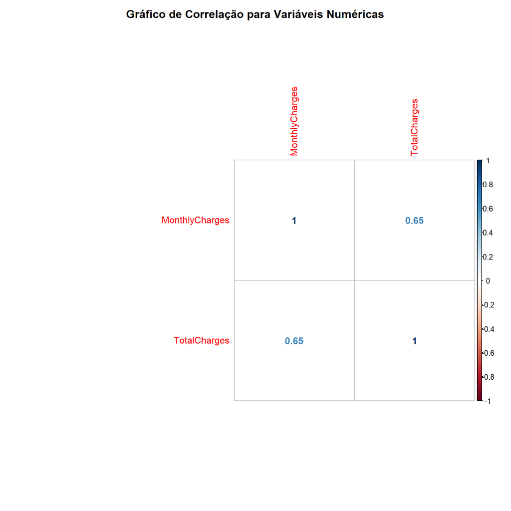

```r
corrplot(corr.matrix, main="\n\nGráfico de Correlação para Variáveis Numéricas", method="number")
```

Os encargos mensais e os encargos totais estão correlacionados. Então, um deles será removido do modelo. Nós removemos Total Charges.

```r
churn$TotalCharges <- NULL
```

**Gráficos de barra de variáveis categóricas**

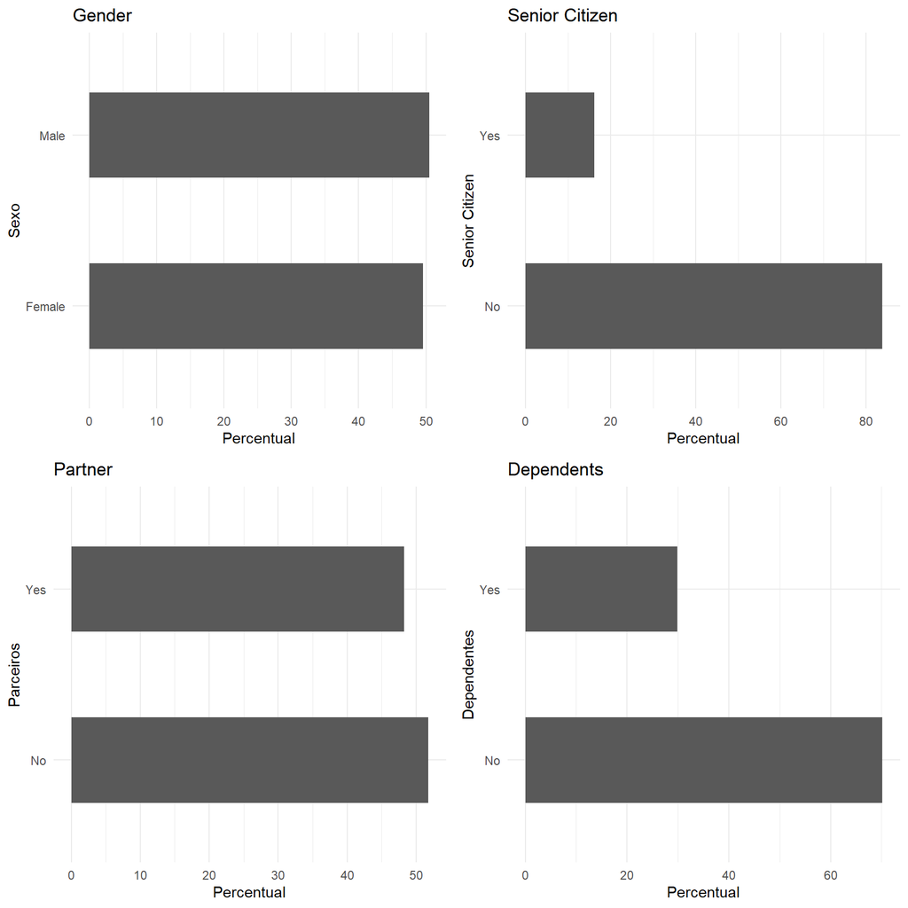

```r
p1 <- ggplot(churn, aes(x=gender)) + ggtitle("Gender") + xlab("Sexo") +
  geom_bar(aes(y = 100*(..count..)/sum(..count..)), width = 0.5) + ylab("Percentual") + coord_flip() + theme_minimal()
p2 <- ggplot(churn, aes(x=SeniorCitizen)) + ggtitle("Senior Citizen") + xlab("Senior Citizen") +
  geom_bar(aes(y = 100*(..count..)/sum(..count..)), width = 0.5) + ylab("Percentual") + coord_flip() + theme_minimal()
p3 <- ggplot(churn, aes(x=Partner)) + ggtitle("Partner") + xlab("Parceiros") +
  geom_bar(aes(y = 100*(..count..)/sum(..count..)), width = 0.5) + ylab("Percentual") + coord_flip() + theme_minimal()
p4 <- ggplot(churn, aes(x=Dependents)) + ggtitle("Dependents") + xlab("Dependentes") +
  geom_bar(aes(y = 100*(..count..)/sum(..count..)), width = 0.5) + ylab("Percentual") + coord_flip() + theme_minimal()
grid.arrange(p1, p2, p3, p4, ncol=2)
```

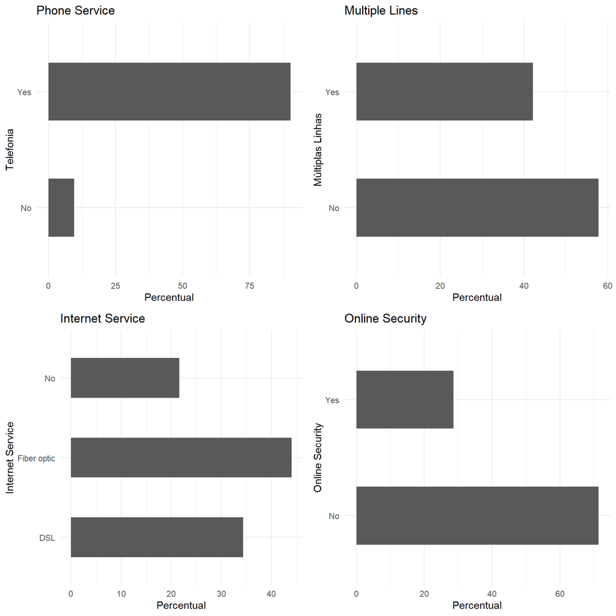

```r
p5 <- ggplot(churn, aes(x=PhoneService)) + ggtitle("Phone Service") + xlab("Telefonia") +
  geom_bar(aes(y = 100*(..count..)/sum(..count..)), width = 0.5) + ylab("Percentual") + coord_flip() + theme_minimal()
p6 <- ggplot(churn, aes(x=MultipleLines)) + ggtitle("Multiple Lines") + xlab("Múltiplas Linhas") +
  geom_bar(aes(y = 100*(..count..)/sum(..count..)), width = 0.5) + ylab("Percentual") + coord_flip() + theme_minimal()
p7 <- ggplot(churn, aes(x=InternetService)) + ggtitle("Internet Service") + xlab("Internet Service") +
  geom_bar(aes(y = 100*(..count..)/sum(..count..)), width = 0.5) + ylab("Percentual") + coord_flip() + theme_minimal()
p8 <- ggplot(churn, aes(x=OnlineSecurity)) + ggtitle("Online Security") + xlab("Online Security") +
  geom_bar(aes(y = 100*(..count..)/sum(..count..)), width = 0.5) + ylab("Percentual") + coord_flip() + theme_minimal()
grid.arrange(p5, p6, p7, p8, ncol=2)
```

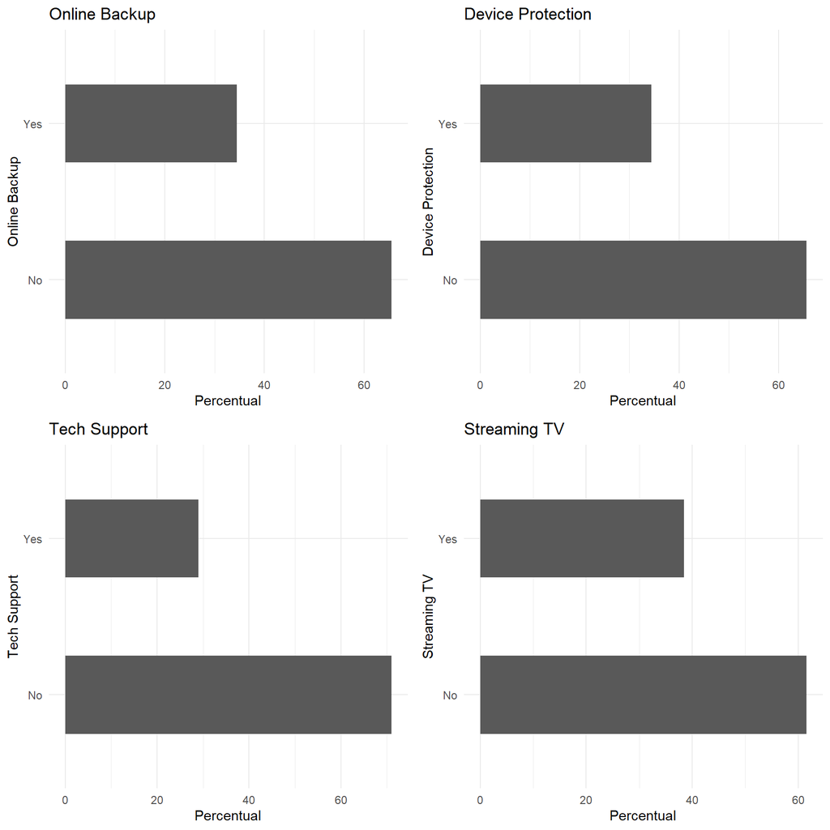

```r
p9 <- ggplot(churn, aes(x=OnlineBackup)) + ggtitle("Online Backup") + xlab("Online Backup") +
  geom_bar(aes(y = 100*(..count..)/sum(..count..)), width = 0.5) + ylab("Percentual") + coord_flip() + theme_minimal()
p10 <- ggplot(churn, aes(x=DeviceProtection)) + ggtitle("Device Protection") + xlab("Device Protection") +
  geom_bar(aes(y = 100*(..count..)/sum(..count..)), width = 0.5) + ylab("Percentual") + coord_flip() + theme_minimal()
p11 <- ggplot(churn, aes(x=TechSupport)) + ggtitle("Tech Support") + xlab("Tech Support") +
  geom_bar(aes(y = 100*(..count..)/sum(..count..)), width = 0.5) + ylab("Percentual") + coord_flip() + theme_minimal()
p12 <- ggplot(churn, aes(x=StreamingTV)) + ggtitle("Streaming TV") + xlab("Streaming TV") +
  geom_bar(aes(y = 100*(..count..)/sum(..count..)), width = 0.5) + ylab("Percentual") + coord_flip() + theme_minimal()
grid.arrange(p9, p10, p11, p12, ncol=2)
```

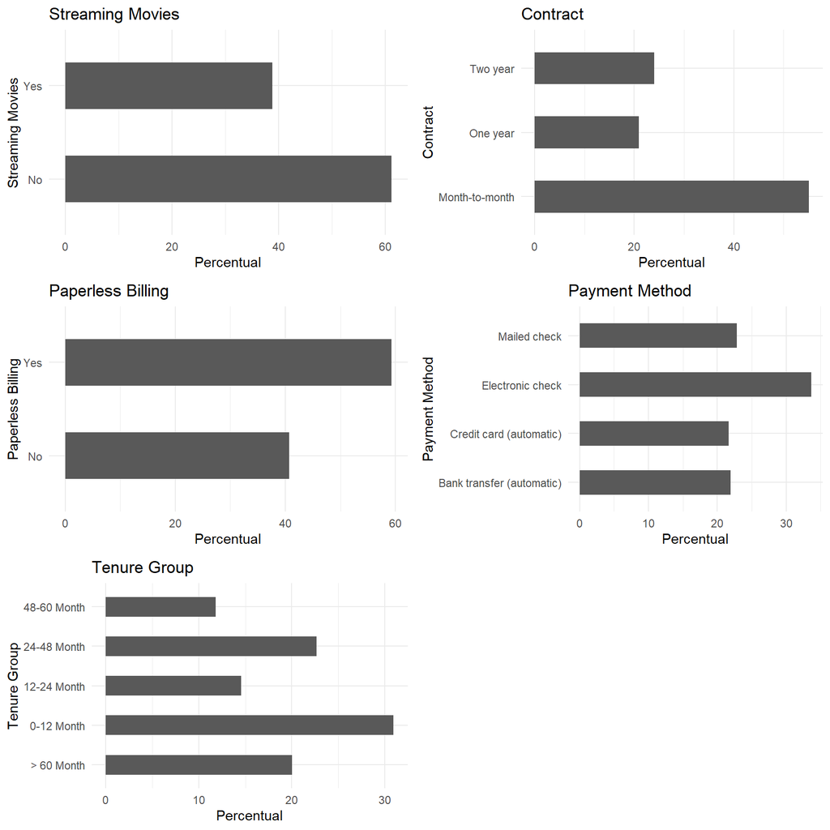

```r
p13 <- ggplot(churn, aes(x=StreamingMovies)) + ggtitle("Streaming Movies") + xlab("Streaming Movies") +
  geom_bar(aes(y = 100*(..count..)/sum(..count..)), width = 0.5) + ylab("Percentual") + coord_flip() + theme_minimal()
p14 <- ggplot(churn, aes(x=Contract)) + ggtitle("Contract") + xlab("Contract") +
  geom_bar(aes(y = 100*(..count..)/sum(..count..)), width = 0.5) + ylab("Percentual") + coord_flip() + theme_minimal()
p15 <- ggplot(churn, aes(x=PaperlessBilling)) + ggtitle("Paperless Billing") + xlab("Paperless Billing") +
  geom_bar(aes(y = 100*(..count..)/sum(..count..)), width = 0.5) + ylab("Percentual") + coord_flip() + theme_minimal()
p16 <- ggplot(churn, aes(x=PaymentMethod)) + ggtitle("Payment Method") + xlab("Payment Method") +
  geom_bar(aes(y = 100*(..count..)/sum(..count..)), width = 0.5) + ylab("Percentual") + coord_flip() + theme_minimal()
p17 <- ggplot(churn, aes(x=tenure_group)) + ggtitle("Tenure Group") + xlab("Tenure Group") +
  geom_bar(aes(y = 100*(..count..)/sum(..count..)), width = 0.5) + ylab("Percentual") + coord_flip() + theme_minimal()
grid.arrange(p13, p14, p15, p16, p17, ncol=2)
```

**Todas as variáveis categóricas parecem ter uma distribuição razoavelmente ampla, portanto, todas elas serão mantidas para análise posterior.**

### Modelagem Preditiva

#### Regressão Logística

**Primeiro, dividimos os dados em conjuntos de treinamento e testes**

```r
intrain <- createDataPartition(churn$Churn,p=0.7,list=FALSE)
set.seed(2017)
training <- churn[intrain,]
testing <- churn[-intrain,]
```

**Confirme se a divisão está correta**

```r
dim(training); dim(testing)
```

```
## [1] 4924   19
```

```
## [1] 2108   19
```

**Treinando o modelo de regressão logística (Fitting do Modelo)**

```r
LogModel <- glm(Churn ~ ., family=binomial(link="logit"), data=training)
print(summary(LogModel))
```

```
##
## Call:
## glm(formula = Churn ~ ., family = binomial(link = "logit"), data = training)
##
## Deviance Residuals:
##     Min       1Q   Median       3Q      Max
## -1.9524  -0.6726  -0.3040   0.6764   3.0787
##
## Coefficients:
##                                       Estimate Std. Error z value Pr(>|z|)
## (Intercept)                          -1.518253   0.971969  -1.562 0.118279
## genderMale                           -0.066303   0.077342  -0.857 0.391299
## SeniorCitizenYes                      0.181179   0.100593   1.801 0.071686 .
## PartnerYes                            0.010502   0.091658   0.115 0.908778
## DependentsYes                        -0.037674   0.104982  -0.359 0.719702
## PhoneServiceYes                      -0.117166   0.767739  -0.153 0.878705
## MultipleLinesYes                      0.365658   0.210477   1.737 0.082337 .
## InternetServiceFiber optic            1.436369   0.943411   1.523 0.127877
## InternetServiceNo                    -1.309862   0.952524  -1.375 0.169085
## OnlineSecurityYes                    -0.280747   0.212413  -1.322 0.186267
## OnlineBackupYes                      -0.060868   0.208113  -0.292 0.769924
## DeviceProtectionYes                   0.026161   0.208383   0.126 0.900094
## TechSupportYes                       -0.206136   0.215703  -0.956 0.339252
## StreamingTVYes                        0.364730   0.387798   0.941 0.346953
## StreamingMoviesYes                    0.424261   0.385956   1.099 0.271661
## ContractOne year                     -0.761440   0.126567  -6.016 1.79e-09 ***
## ContractTwo year                     -1.587089   0.206991  -7.667 1.75e-14 ***
## PaperlessBillingYes                   0.264746   0.088899   2.978 0.002901 **
## PaymentMethodCredit card (automatic) -0.017164   0.134936  -0.127 0.898783
## PaymentMethodElectronic check         0.382120   0.112414   3.399 0.000676 ***
## PaymentMethodMailed check             0.002509   0.136498   0.018 0.985335
## MonthlyCharges                       -0.017722   0.037499  -0.473 0.636502
## tenure_group0-12 Month                1.708598   0.200272   8.531  < 2e-16 ***
## tenure_group12-24 Month               0.767299   0.195933   3.916 9.00e-05 ***
## tenure_group24-48 Month               0.533069   0.178846   2.981 0.002877 **
## tenure_group48-60 Month               0.255823   0.194150   1.318 0.187619
## ---
## Signif. codes:  0 '***' 0.001 '**' 0.01 '*' 0.05 '.' 0.1 ' ' 1
##
## (Dispersion parameter for binomial family taken to be 1)
##
##     Null deviance: 5702.8  on 4923  degrees of freedom
## Residual deviance: 4131.1  on 4898  degrees of freedom
## AIC: 4183.1
##
## Number of Fisher Scoring iterations: 6
```

#### Análise de Variância - ANOVA

```r
anova(LogModel, test="Chisq")
```

```
## Analysis of Deviance Table
##
## Model: binomial, link: logit
##
## Response: Churn
##
## Terms added sequentially (first to last)
##
##
##                  Df Deviance Resid. Df Resid. Dev  Pr(>Chi)
## NULL                              4923     5702.8
## gender            1     1.09      4922     5701.7  0.295991
## SeniorCitizen     1    98.98      4921     5602.7 < 2.2e-16 ***
## Partner           1    96.45      4920     5506.2 < 2.2e-16 ***
## Dependents        1    25.50      4919     5480.7 4.415e-07 ***
## PhoneService      1     2.59      4918     5478.1  0.107803
## MultipleLines     1     7.23      4917     5470.9  0.007167 **
## InternetService   2   492.11      4915     4978.8 < 2.2e-16 ***
## OnlineSecurity    1   162.21      4914     4816.6 < 2.2e-16 ***
## OnlineBackup      1    77.29      4913     4739.3 < 2.2e-16 ***
## DeviceProtection  1    57.88      4912     4681.4 2.792e-14 ***
## TechSupport       1    69.09      4911     4612.3 < 2.2e-16 ***
## StreamingTV       1     0.30      4910     4612.0  0.582062
## StreamingMovies   1     0.57      4909     4611.5  0.451952
## Contract          2   285.52      4907     4325.9 < 2.2e-16 ***
## PaperlessBilling  1     9.37      4906     4316.6  0.002207 **
## PaymentMethod     3    37.51      4903     4279.1 3.590e-08 ***
## MonthlyCharges    1     0.12      4902     4279.0  0.733735
## tenure_group      4   147.87      4898     4131.1 < 2.2e-16 ***
## ---
## Signif. codes:  0 '***' 0.001 '**' 0.01 '*' 0.05 '.' 0.1 ' ' 1
```

**Analisando a tabela de variância, podemos ver a queda no desvio ao adicionar cada variável uma de cada vez. Adicionar InternetService, Contract e tenure_group reduz significativamente o desvio residual. As outras variáveis, como PaymentMethod e Dependents, parecem melhorar menos o modelo, embora todos tenham valores p baixos.**

```r
testing$Churn <- as.character(testing$Churn)
testing$Churn[testing$Churn=="No"] <- "0"
testing$Churn[testing$Churn=="Yes"] <- "1"
fitted.results <- predict(LogModel,newdata=testing,type='response')
fitted.results <- ifelse(fitted.results > 0.5,1,0)
misClasificError <- mean(fitted.results != testing$Churn)
print(paste('Logistic Regression Accuracy',1-misClasificError))
```

```
## [1] "Logistic Regression Accuracy 0.790322580645161"
```

**Matriz de Confusão de Regressão Logística**

```r
print("Confusion Matrix Para Logistic Regression"); table(testing$Churn, fitted.results > 0.5)
```

```
## [1] "Confusion Matrix Para Logistic Regression"
```

```
##
##     FALSE TRUE
##   0  1383  165
##   1   277  283
```

**Odds Ratio**

**Uma das medidas de desempenho interessantes na regressão logística é Odds Ratio. Basicamente, odds ratio é a chance de um evento acontecer.**

```r
exp(cbind(OR=coef(LogModel), confint(LogModel)))
```

```
##                                             OR      2.5 %     97.5 %
## (Intercept)                          0.2190942 0.03254930  1.4713745
## genderMale                           0.9358477 0.80417324  1.0890382
## SeniorCitizenYes                     1.1986295 0.98387017  1.4595983
## PartnerYes                           1.0105576 0.84444930  1.2096267
## DependentsYes                        0.9630272 0.78346095  1.1825027
## PhoneServiceYes                      0.8894376 0.19749763  4.0082258
## MultipleLinesYes                     1.4414624 0.95445943  2.1786237
## InternetServiceFiber optic           4.2053970 0.66311774 26.8001900
## InternetServiceNo                    0.2698573 0.04165866  1.7449073
## OnlineSecurityYes                    0.7552193 0.49779965  1.1449217
## OnlineBackupYes                      0.9409479 0.62572108  1.4150637
## DeviceProtectionYes                  1.0265060 0.68226234  1.5445785
## TechSupportYes                       0.8137227 0.53287053  1.2415123
## StreamingTVYes                       1.4401248 0.67375502  3.0824066
## StreamingMoviesYes                   1.5284601 0.71767619  3.2597012
## ContractOne year                     0.4669934 0.36333971  0.5969304
## ContractTwo year                     0.2045202 0.13469700  0.3036640
## PaperlessBillingYes                  1.3031003 1.09500385  1.5516687
## PaymentMethodCredit card (automatic) 0.9829827 0.75432842  1.2805456
## PaymentMethodElectronic check        1.4653879 1.17660031  1.8284613
## PaymentMethodMailed check            1.0025122 0.76746360  1.3107601
## MonthlyCharges                       0.9824344 0.91274802  1.0573247
## tenure_group0-12 Month               5.5212134 3.74178442  8.2080406
## tenure_group12-24 Month              2.1539412 1.47086954  3.1723348
## tenure_group24-48 Month              1.7041540 1.20373924  2.4282540
## tenure_group48-60 Month              1.2915237 0.88285511  1.8914182
```

#### Árvore de Decisão

**Para fins de ilustração, vamos usar apenas três variáveis para plotar árvores de decisão, elas são “Contrato”, “tenure_group” e “PaperlessBilling”.**

```r
tree <- ctree(Churn ~ Contract+tenure_group+PaperlessBilling, training)
```

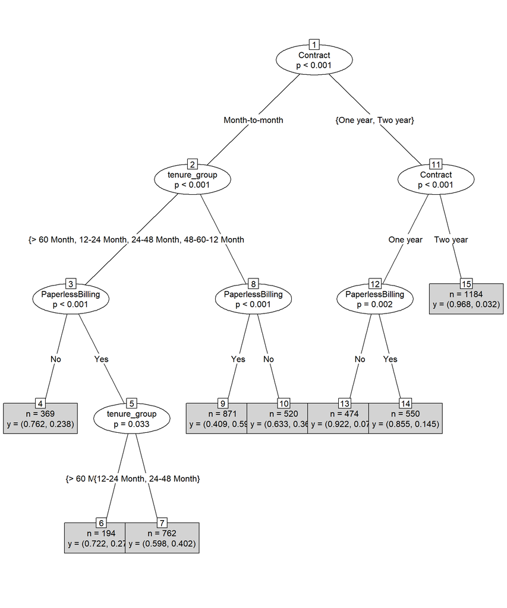

```r
plot(tree, type='simple')
```

1. Das três variáveis que usamos, o Contrato é a variável mais importante para prever a rotatividade de clientes ou não.
2. Se um cliente em um contrato de um ano ou de dois anos, não importa se ele (ela) tem ou não a PapelessBilling, ele (ela) é menos propenso a se cancelar a assinatura.
3. Por outro lado, se um cliente estiver em um contrato mensal, e no grupo de posse de 0 a 12 meses, e usando o PaperlessBilling, esse cliente terá mais chances de cancelar a assinatura.

```r
pred_tree <- predict(tree, testing)
print("Confusion Matrix Para Decision Tree"); table(Predicted = pred_tree, Actual = testing$Churn)
```

```
## [1] "Confusion Matrix Para Decision Tree"
```

```
##          Actual
## Predicted    0    1
##       No  1405  342
##       Yes  143  218
```

**Precisão da árvore de decisão**

```r
p1 <- predict(tree, training)
tab1 <- table(Predicted = p1, Actual = training$Churn)
tab2 <- table(Predicted = pred_tree, Actual = testing$Churn)
print(paste('Decision Tree Accuracy',sum(diag(tab2))/sum(tab2)))
```

```
## [1] "Decision Tree Accuracy 0.769924098671727"
```

#### Random Forest

```r
set.seed(2017)
rfModel <- randomForest(Churn ~ ., data = training)
print(rfModel)
```

```
##
## Call:
##  randomForest(formula = Churn ~ ., data = training)
##                Type of random forest: classification
##                      Number of trees: 500
## No. of variables tried at each split: 4
##
##         OOB estimate of  error rate: 20.63%
## Confusion matrix:
##       No Yes class.error
## No  3248 367   0.1015214
## Yes  649 660   0.4957983
```

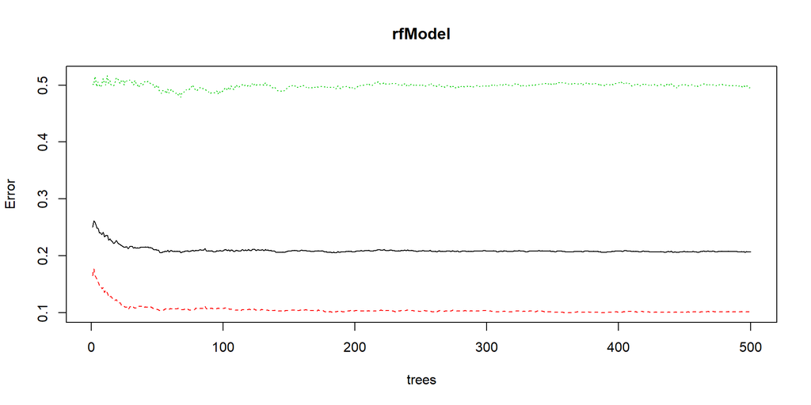

```r
plot(rfModel)
```

**A previsão é muito boa ao prever “Não”. A taxa de erros é muito maior quando se prevê “sim”.**

**Prevendo valores com dados de teste**

```r
pred_rf <- predict(rfModel, testing)
```

**Confusion Matrix**

```r
print("Confusion Matrix Para Random Forest"); table(testing$Churn, pred_rf)
```

```
## [1] "Confusion Matrix Para Random Forest"
```

```
##    pred_rf
##       No  Yes
##   0 1383  165
##   1  279  281
```

**Recursos mais importantes**

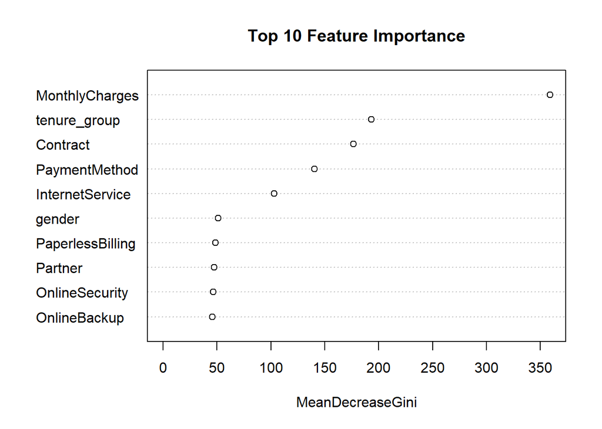

```r
varImpPlot(rfModel, sort=T, n.var = 10, main = 'Top 10 Feature Importance')
```